# Risk Factor Analysis

## Outcome Variable

**Outcome Variable:** haz

## Predictor Variables

**Intervention Variable:** mbmi

**Adjustment Set:**

- arm
- W_mage
- W_fage
- meducyrs
- feducyrs
- single
- brthmon
- W_gagebrth
- W_birthwt
- W_birthlen
- vagbrth
- delta_W_mage
- delta_W_fage
- delta_meducyrs
- delta_feducyrs
- delta_single
- delta_brthmon
- delta_W_gagebrth
- delta_W_birthwt
- delta_W_birthlen
- delta_vagbrth

## Stratifying Variables

The analysis was stratified on these variable(s):

- agecat
- studyid
- country

## Data Summary

| agecat | studyid | country | mbmi | n_cell | n |
| --- | --- | --- | --- | --- | --- |
| 6 months | ki0047075b-MAL-ED | BANGLADESH | Normal weight | 209 | 241 |
| 6 months | ki0047075b-MAL-ED | BANGLADESH | Underweight | 32 | 241 |
| 6 months | ki0047075b-MAL-ED | BRAZIL | Normal weight | 199 | 208 |
| 6 months | ki0047075b-MAL-ED | BRAZIL | Underweight | 9 | 208 |
| 6 months | ki0047075b-MAL-ED | INDIA | Normal weight | 186 | 235 |
| 6 months | ki0047075b-MAL-ED | INDIA | Underweight | 49 | 235 |
| 6 months | ki0047075b-MAL-ED | NEPAL | Normal weight | 236 | 236 |
| 6 months | ki0047075b-MAL-ED | NEPAL | Underweight | 0 | 236 |
| 6 months | ki0047075b-MAL-ED | PERU | Normal weight | 267 | 272 |
| 6 months | ki0047075b-MAL-ED | PERU | Underweight | 5 | 272 |
| 6 months | ki0047075b-MAL-ED | SOUTH AFRICA | Normal weight | 242 | 249 |
| 6 months | ki0047075b-MAL-ED | SOUTH AFRICA | Underweight | 7 | 249 |
| 6 months | ki0047075b-MAL-ED | TANZANIA, UNITED REPUBLIC OF | Normal weight | 233 | 247 |
| 6 months | ki0047075b-MAL-ED | TANZANIA, UNITED REPUBLIC OF | Underweight | 14 | 247 |
| 6 months | ki1000304b-SAS-CompFeed | INDIA | Normal weight | 922 | 1227 |
| 6 months | ki1000304b-SAS-CompFeed | INDIA | Underweight | 305 | 1227 |
| 6 months | ki1017093-NIH-Birth | BANGLADESH | Normal weight | 444 | 537 |
| 6 months | ki1017093-NIH-Birth | BANGLADESH | Underweight | 93 | 537 |
| 6 months | ki1017093b-PROVIDE | BANGLADESH | Normal weight | 481 | 582 |
| 6 months | ki1017093b-PROVIDE | BANGLADESH | Underweight | 101 | 582 |
| 6 months | ki1017093c-NIH-Crypto | BANGLADESH | Normal weight | 648 | 715 |
| 6 months | ki1017093c-NIH-Crypto | BANGLADESH | Underweight | 67 | 715 |
| 6 months | ki1066203-TanzaniaChild2 | TANZANIA, UNITED REPUBLIC OF | Normal weight | 1949 | 1983 |
| 6 months | ki1066203-TanzaniaChild2 | TANZANIA, UNITED REPUBLIC OF | Underweight | 34 | 1983 |
| 6 months | ki1119695-PROBIT | BELARUS | Normal weight | 12522 | 13027 |
| 6 months | ki1119695-PROBIT | BELARUS | Underweight | 505 | 13027 |
| 6 months | ki1126311-ZVITAMBO | ZIMBABWE | Normal weight | 6747 | 7109 |
| 6 months | ki1126311-ZVITAMBO | ZIMBABWE | Underweight | 362 | 7109 |
| 6 months | ki1148112-LCNI-5 | MALAWI | Normal weight | 691 | 836 |
| 6 months | ki1148112-LCNI-5 | MALAWI | Underweight | 145 | 836 |
| 24 months | ki0047075b-MAL-ED | BANGLADESH | Normal weight | 183 | 212 |
| 24 months | ki0047075b-MAL-ED | BANGLADESH | Underweight | 29 | 212 |
| 24 months | ki0047075b-MAL-ED | BRAZIL | Normal weight | 162 | 168 |
| 24 months | ki0047075b-MAL-ED | BRAZIL | Underweight | 6 | 168 |
| 24 months | ki0047075b-MAL-ED | INDIA | Normal weight | 180 | 226 |
| 24 months | ki0047075b-MAL-ED | INDIA | Underweight | 46 | 226 |
| 24 months | ki0047075b-MAL-ED | NEPAL | Normal weight | 228 | 228 |
| 24 months | ki0047075b-MAL-ED | NEPAL | Underweight | 0 | 228 |
| 24 months | ki0047075b-MAL-ED | PERU | Normal weight | 197 | 201 |
| 24 months | ki0047075b-MAL-ED | PERU | Underweight | 4 | 201 |
| 24 months | ki0047075b-MAL-ED | SOUTH AFRICA | Normal weight | 227 | 234 |
| 24 months | ki0047075b-MAL-ED | SOUTH AFRICA | Underweight | 7 | 234 |
| 24 months | ki0047075b-MAL-ED | TANZANIA, UNITED REPUBLIC OF | Normal weight | 203 | 214 |
| 24 months | ki0047075b-MAL-ED | TANZANIA, UNITED REPUBLIC OF | Underweight | 11 | 214 |
| 24 months | ki1017093-NIH-Birth | BANGLADESH | Normal weight | 349 | 429 |
| 24 months | ki1017093-NIH-Birth | BANGLADESH | Underweight | 80 | 429 |
| 24 months | ki1017093b-PROVIDE | BANGLADESH | Normal weight | 476 | 576 |
| 24 months | ki1017093b-PROVIDE | BANGLADESH | Underweight | 100 | 576 |
| 24 months | ki1017093c-NIH-Crypto | BANGLADESH | Normal weight | 471 | 514 |
| 24 months | ki1017093c-NIH-Crypto | BANGLADESH | Underweight | 43 | 514 |
| 24 months | ki1066203-TanzaniaChild2 | TANZANIA, UNITED REPUBLIC OF | Normal weight | 6 | 6 |
| 24 months | ki1066203-TanzaniaChild2 | TANZANIA, UNITED REPUBLIC OF | Underweight | 0 | 6 |
| 24 months | ki1119695-PROBIT | BELARUS | Normal weight | 3863 | 4005 |
| 24 months | ki1119695-PROBIT | BELARUS | Underweight | 142 | 4005 |
| 24 months | ki1126311-ZVITAMBO | ZIMBABWE | Normal weight | 352 | 377 |
| 24 months | ki1126311-ZVITAMBO | ZIMBABWE | Underweight | 25 | 377 |
| 24 months | ki1148112-LCNI-5 | MALAWI | Normal weight | 482 | 577 |
| 24 months | ki1148112-LCNI-5 | MALAWI | Underweight | 95 | 577 |

The following strata were considered:

- agecat: 24 months, studyid: ki0047075b-MAL-ED, country: BANGLADESH
- agecat: 24 months, studyid: ki0047075b-MAL-ED, country: BRAZIL
- agecat: 24 months, studyid: ki0047075b-MAL-ED, country: INDIA
- agecat: 24 months, studyid: ki0047075b-MAL-ED, country: NEPAL
- agecat: 24 months, studyid: ki0047075b-MAL-ED, country: PERU
- agecat: 24 months, studyid: ki0047075b-MAL-ED, country: SOUTH AFRICA
- agecat: 24 months, studyid: ki0047075b-MAL-ED, country: TANZANIA, UNITED REPUBLIC OF
- agecat: 24 months, studyid: ki1017093-NIH-Birth, country: BANGLADESH
- agecat: 24 months, studyid: ki1017093b-PROVIDE, country: BANGLADESH
- agecat: 24 months, studyid: ki1017093c-NIH-Crypto, country: BANGLADESH
- agecat: 24 months, studyid: ki1066203-TanzaniaChild2, country: TANZANIA, UNITED REPUBLIC OF
- agecat: 24 months, studyid: ki1119695-PROBIT, country: BELARUS
- agecat: 24 months, studyid: ki1126311-ZVITAMBO, country: ZIMBABWE
- agecat: 24 months, studyid: ki1148112-LCNI-5, country: MALAWI
- agecat: 6 months, studyid: ki0047075b-MAL-ED, country: BANGLADESH
- agecat: 6 months, studyid: ki0047075b-MAL-ED, country: BRAZIL
- agecat: 6 months, studyid: ki0047075b-MAL-ED, country: INDIA
- agecat: 6 months, studyid: ki0047075b-MAL-ED, country: NEPAL
- agecat: 6 months, studyid: ki0047075b-MAL-ED, country: PERU
- agecat: 6 months, studyid: ki0047075b-MAL-ED, country: SOUTH AFRICA
- agecat: 6 months, studyid: ki0047075b-MAL-ED, country: TANZANIA, UNITED REPUBLIC OF
- agecat: 6 months, studyid: ki1000304b-SAS-CompFeed, country: INDIA
- agecat: 6 months, studyid: ki1017093-NIH-Birth, country: BANGLADESH
- agecat: 6 months, studyid: ki1017093b-PROVIDE, country: BANGLADESH
- agecat: 6 months, studyid: ki1017093c-NIH-Crypto, country: BANGLADESH
- agecat: 6 months, studyid: ki1066203-TanzaniaChild2, country: TANZANIA, UNITED REPUBLIC OF
- agecat: 6 months, studyid: ki1119695-PROBIT, country: BELARUS
- agecat: 6 months, studyid: ki1126311-ZVITAMBO, country: ZIMBABWE
- agecat: 6 months, studyid: ki1148112-LCNI-5, country: MALAWI

### Dropped Strata

Some strata were dropped due to rare outcomes:

- agecat: 6 months, studyid: ki0047075b-MAL-ED, country: NEPAL
- agecat: 24 months, studyid: ki0047075b-MAL-ED, country: NEPAL
- agecat: 24 months, studyid: ki0047075b-MAL-ED, country: PERU
- agecat: 24 months, studyid: ki1066203-TanzaniaChild2, country: TANZANIA, UNITED REPUBLIC OF

## Methods Detail

We’re interested in the causal parameters $E[Y_a]$ for all values of $a \in \mathcal{A}$. These parameters represent the mean outcome if, possibly contrary to fact, we intervened to set all units to have $A=a$. Under the randomization and positivity assumptions, these are identified by the statistical parameters $\psi_a=E_W[E_{Y|A,W}(Y|A=a,W)]$. In addition, we’re interested in the mean of $Y$, $E[Y]$ under no intervention (the observed mean). We will estimate these parameters by using SuperLearner to fit the relevant likelihood factors – $E_{Y|A,W}(Y|A=a,W)$ and $p(A=a|W)$, and then updating our likelihood fit using a joint TMLE.

For unadjusted analyses ($W=\{\}$), initial likelihoods were estimated using Lrnr_glm to estimate the simple $E(Y|A)$ and Lrnr_mean to estimate $p(A)$. For adjusted analyses, a small library containing Lrnr_glmnet, Lrnr_xgboost, and Lrnr_mean was used.

Having estimated these parameters, we will then use the delta method to estimate relative risks and attributable risks relative to a prespecified baseline level of $A$.

# Results Detail

## Results Plots

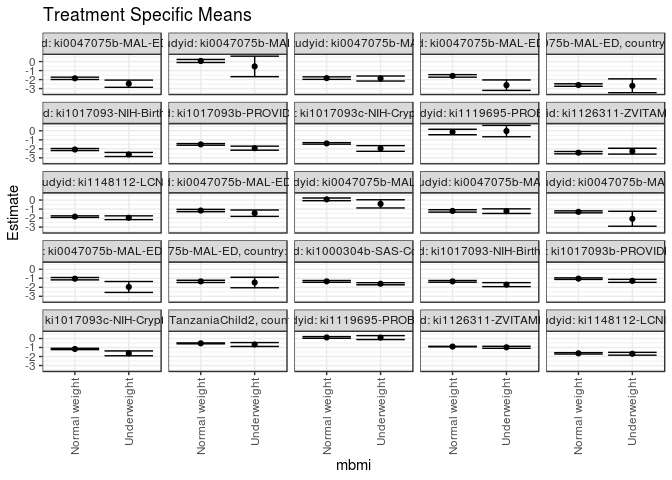

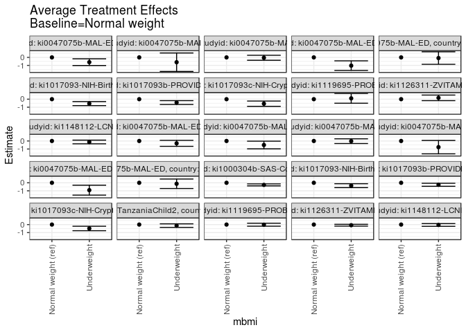

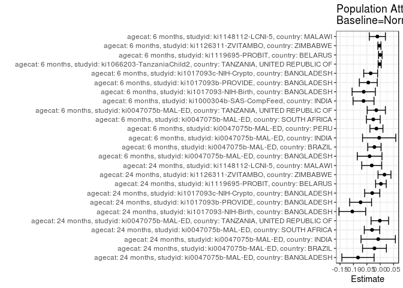

## Results Table

### Parameter: TSM

| agecat | studyid | country | intervention_level | baseline_level | estimate | ci_lower | ci_upper |
| --- | --- | --- | --- | --- | --- | --- | --- |
| 6 months | ki0047075b-MAL-ED | BANGLADESH | Normal weight | NA | -1.1660172 | -1.2918125 | -1.0402220 |
| 6 months | ki0047075b-MAL-ED | BANGLADESH | Underweight | NA | -1.4590345 | -1.8113845 | -1.1066845 |
| 6 months | ki0047075b-MAL-ED | BRAZIL | Normal weight | NA | 0.0748995 | -0.0742030 | 0.2240020 |
| 6 months | ki0047075b-MAL-ED | BRAZIL | Underweight | NA | -0.4262963 | -0.8810079 | 0.0284153 |
| 6 months | ki0047075b-MAL-ED | INDIA | Normal weight | NA | -1.2108323 | -1.3435657 | -1.0780989 |
| 6 months | ki0047075b-MAL-ED | INDIA | Underweight | NA | -1.2339041 | -1.4921166 | -0.9756917 |
| 6 months | ki0047075b-MAL-ED | PERU | Normal weight | NA | -1.3131149 | -1.4218494 | -1.2043803 |
| 6 months | ki0047075b-MAL-ED | PERU | Underweight | NA | -2.0820000 | -2.9100519 | -1.2539481 |
| 6 months | ki0047075b-MAL-ED | SOUTH AFRICA | Normal weight | NA | -1.0469731 | -1.1780219 | -0.9159244 |
| 6 months | ki0047075b-MAL-ED | SOUTH AFRICA | Underweight | NA | -1.9657143 | -2.5717876 | -1.3596410 |
| 6 months | ki0047075b-MAL-ED | TANZANIA, UNITED REPUBLIC OF | Normal weight | NA | -1.3454157 | -1.4694269 | -1.2214046 |
| 6 months | ki0047075b-MAL-ED | TANZANIA, UNITED REPUBLIC OF | Underweight | NA | -1.4706479 | -2.0518741 | -0.8894217 |
| 6 months | ki1000304b-SAS-CompFeed | INDIA | Normal weight | NA | -1.3449333 | -1.4429227 | -1.2469439 |
| 6 months | ki1000304b-SAS-CompFeed | INDIA | Underweight | NA | -1.6092659 | -1.7247064 | -1.4938253 |
| 6 months | ki1017093-NIH-Birth | BANGLADESH | Normal weight | NA | -1.3457913 | -1.4408094 | -1.2507733 |
| 6 months | ki1017093-NIH-Birth | BANGLADESH | Underweight | NA | -1.7068640 | -1.9304352 | -1.4832929 |
| 6 months | ki1017093b-PROVIDE | BANGLADESH | Normal weight | NA | -1.0402474 | -1.1250901 | -0.9554047 |
| 6 months | ki1017093b-PROVIDE | BANGLADESH | Underweight | NA | -1.2901130 | -1.4570356 | -1.1231904 |
| 6 months | ki1017093c-NIH-Crypto | BANGLADESH | Normal weight | NA | -1.1630359 | -1.2368621 | -1.0892097 |
| 6 months | ki1017093c-NIH-Crypto | BANGLADESH | Underweight | NA | -1.6484352 | -1.9149698 | -1.3819007 |
| 6 months | ki1066203-TanzaniaChild2 | TANZANIA, UNITED REPUBLIC OF | Normal weight | NA | -0.5384425 | -0.5887195 | -0.4881654 |
| 6 months | ki1066203-TanzaniaChild2 | TANZANIA, UNITED REPUBLIC OF | Underweight | NA | -0.6694908 | -0.8855051 | -0.4534764 |
| 6 months | ki1119695-PROBIT | BELARUS | Normal weight | NA | 0.1151457 | 0.0224689 | 0.2078226 |
| 6 months | ki1119695-PROBIT | BELARUS | Underweight | NA | 0.1006228 | -0.1170408 | 0.3182865 |
| 6 months | ki1126311-ZVITAMBO | ZIMBABWE | Normal weight | NA | -0.8978225 | -0.9262007 | -0.8694444 |
| 6 months | ki1126311-ZVITAMBO | ZIMBABWE | Underweight | NA | -0.9775591 | -1.0871831 | -0.8679351 |
| 6 months | ki1148112-LCNI-5 | MALAWI | Normal weight | NA | -1.6470786 | -1.7252550 | -1.5689021 |
| 6 months | ki1148112-LCNI-5 | MALAWI | Underweight | NA | -1.6943814 | -1.8494563 | -1.5393064 |
| 24 months | ki0047075b-MAL-ED | BANGLADESH | Normal weight | NA | -1.8601107 | -1.9906782 | -1.7295432 |
| 24 months | ki0047075b-MAL-ED | BANGLADESH | Underweight | NA | -2.4549849 | -2.8547014 | -2.0552684 |
| 24 months | ki0047075b-MAL-ED | BRAZIL | Normal weight | NA | 0.0633642 | -0.1049962 | 0.2317246 |
| 24 months | ki0047075b-MAL-ED | BRAZIL | Underweight | NA | -0.5391667 | -1.6773310 | 0.5989977 |
| 24 months | ki0047075b-MAL-ED | INDIA | Normal weight | NA | -1.8363382 | -1.9777808 | -1.6948956 |
| 24 months | ki0047075b-MAL-ED | INDIA | Underweight | NA | -1.8831293 | -2.1589199 | -1.6073387 |
| 24 months | ki0047075b-MAL-ED | SOUTH AFRICA | Normal weight | NA | -1.5912775 | -1.7294629 | -1.4530921 |
| 24 months | ki0047075b-MAL-ED | SOUTH AFRICA | Underweight | NA | -2.6192857 | -3.1998173 | -2.0387542 |
| 24 months | ki0047075b-MAL-ED | TANZANIA, UNITED REPUBLIC OF | Normal weight | NA | -2.6043081 | -2.7418604 | -2.4667558 |
| 24 months | ki0047075b-MAL-ED | TANZANIA, UNITED REPUBLIC OF | Underweight | NA | -2.6880536 | -3.4559307 | -1.9201764 |
| 24 months | ki1017093-NIH-Birth | BANGLADESH | Normal weight | NA | -2.0766577 | -2.1901531 | -1.9631624 |
| 24 months | ki1017093-NIH-Birth | BANGLADESH | Underweight | NA | -2.6268181 | -2.8528019 | -2.4008343 |
| 24 months | ki1017093b-PROVIDE | BANGLADESH | Normal weight | NA | -1.5105918 | -1.6000758 | -1.4211077 |
| 24 months | ki1017093b-PROVIDE | BANGLADESH | Underweight | NA | -1.9310255 | -2.1534685 | -1.7085825 |
| 24 months | ki1017093c-NIH-Crypto | BANGLADESH | Normal weight | NA | -1.3996161 | -1.4861621 | -1.3130702 |
| 24 months | ki1017093c-NIH-Crypto | BANGLADESH | Underweight | NA | -1.9600893 | -2.2756093 | -1.6445693 |
| 24 months | ki1119695-PROBIT | BELARUS | Normal weight | NA | -0.1347997 | -0.4386406 | 0.1690412 |
| 24 months | ki1119695-PROBIT | BELARUS | Underweight | NA | -0.0306201 | -0.6628745 | 0.6016343 |
| 24 months | ki1126311-ZVITAMBO | ZIMBABWE | Normal weight | NA | -2.4293672 | -2.5586821 | -2.3000523 |
| 24 months | ki1126311-ZVITAMBO | ZIMBABWE | Underweight | NA | -2.2623444 | -2.5862405 | -1.9384482 |
| 24 months | ki1148112-LCNI-5 | MALAWI | Normal weight | NA | -1.8427478 | -1.9320844 | -1.7534112 |
| 24 months | ki1148112-LCNI-5 | MALAWI | Underweight | NA | -1.9649912 | -2.1735970 | -1.7563855 |

### Parameter: E(Y)

| agecat | studyid | country | intervention_level | baseline_level | estimate | ci_lower | ci_upper |
| --- | --- | --- | --- | --- | --- | --- | --- |
| 6 months | ki0047075b-MAL-ED | BANGLADESH | NA | NA | -1.2056777 | -1.3231497 | -1.0882058 |
| 6 months | ki0047075b-MAL-ED | BRAZIL | NA | NA | 0.0532131 | -0.0914567 | 0.1978830 |
| 6 months | ki0047075b-MAL-ED | INDIA | NA | NA | -1.2148369 | -1.3332371 | -1.0964367 |
| 6 months | ki0047075b-MAL-ED | PERU | NA | NA | -1.3272488 | -1.4359649 | -1.2185326 |
| 6 months | ki0047075b-MAL-ED | SOUTH AFRICA | NA | NA | -1.0728012 | -1.2026830 | -0.9429194 |
| 6 months | ki0047075b-MAL-ED | TANZANIA, UNITED REPUBLIC OF | NA | NA | -1.3601215 | -1.4821830 | -1.2380600 |
| 6 months | ki1000304b-SAS-CompFeed | INDIA | NA | NA | -1.4072209 | -1.4983514 | -1.3160903 |
| 6 months | ki1017093-NIH-Birth | BANGLADESH | NA | NA | -1.4073821 | -1.4960598 | -1.3187043 |
| 6 months | ki1017093b-PROVIDE | BANGLADESH | NA | NA | -1.0848568 | -1.1613109 | -1.0084028 |
| 6 months | ki1017093c-NIH-Crypto | BANGLADESH | NA | NA | -1.1986783 | -1.2700937 | -1.1272630 |
| 6 months | ki1066203-TanzaniaChild2 | TANZANIA, UNITED REPUBLIC OF | NA | NA | -0.5405711 | -0.5899965 | -0.4911457 |
| 6 months | ki1119695-PROBIT | BELARUS | NA | NA | 0.1153731 | 0.0222128 | 0.2085334 |
| 6 months | ki1126311-ZVITAMBO | ZIMBABWE | NA | NA | -0.9008757 | -0.9285733 | -0.8731780 |
| 6 months | ki1148112-LCNI-5 | MALAWI | NA | NA | -1.6577751 | -1.7275296 | -1.5880207 |
| 24 months | ki0047075b-MAL-ED | BANGLADESH | NA | NA | -1.9431132 | -2.0691678 | -1.8170586 |
| 24 months | ki0047075b-MAL-ED | BRAZIL | NA | NA | 0.0418452 | -0.1263708 | 0.2100613 |
| 24 months | ki0047075b-MAL-ED | INDIA | NA | NA | -1.8439159 | -1.9704751 | -1.7173568 |
| 24 months | ki0047075b-MAL-ED | SOUTH AFRICA | NA | NA | -1.6220299 | -1.7590593 | -1.4850005 |
| 24 months | ki0047075b-MAL-ED | TANZANIA, UNITED REPUBLIC OF | NA | NA | -2.6058879 | -2.7403043 | -2.4714714 |
| 24 months | ki1017093-NIH-Birth | BANGLADESH | NA | NA | -2.1807945 | -2.2835902 | -2.0779987 |
| 24 months | ki1017093b-PROVIDE | BANGLADESH | NA | NA | -1.5839236 | -1.6672059 | -1.5006413 |
| 24 months | ki1017093c-NIH-Crypto | BANGLADESH | NA | NA | -1.4295331 | -1.5127726 | -1.3462935 |
| 24 months | ki1119695-PROBIT | BELARUS | NA | NA | -0.1322181 | -0.4300523 | 0.1656161 |
| 24 months | ki1126311-ZVITAMBO | ZIMBABWE | NA | NA | -2.4135279 | -2.5366872 | -2.2903685 |
| 24 months | ki1148112-LCNI-5 | MALAWI | NA | NA | -1.8744367 | -1.9556750 | -1.7931984 |

### Parameter: ATE

| agecat | studyid | country | intervention_level | baseline_level | estimate | ci_lower | ci_upper |
| --- | --- | --- | --- | --- | --- | --- | --- |
| 6 months | ki0047075b-MAL-ED | BANGLADESH | Normal weight | Normal weight | 0.0000000 | 0.0000000 | 0.0000000 |
| 6 months | ki0047075b-MAL-ED | BANGLADESH | Underweight | Normal weight | -0.2930173 | -0.6675372 | 0.0815025 |
| 6 months | ki0047075b-MAL-ED | BRAZIL | Normal weight | Normal weight | 0.0000000 | 0.0000000 | 0.0000000 |
| 6 months | ki0047075b-MAL-ED | BRAZIL | Underweight | Normal weight | -0.5011958 | -0.9797291 | -0.0226625 |
| 6 months | ki0047075b-MAL-ED | INDIA | Normal weight | Normal weight | 0.0000000 | 0.0000000 | 0.0000000 |
| 6 months | ki0047075b-MAL-ED | INDIA | Underweight | Normal weight | -0.0230718 | -0.3157840 | 0.2696403 |
| 6 months | ki0047075b-MAL-ED | PERU | Normal weight | Normal weight | 0.0000000 | 0.0000000 | 0.0000000 |
| 6 months | ki0047075b-MAL-ED | PERU | Underweight | Normal weight | -0.7688851 | -1.6040457 | 0.0662754 |
| 6 months | ki0047075b-MAL-ED | SOUTH AFRICA | Normal weight | Normal weight | 0.0000000 | 0.0000000 | 0.0000000 |
| 6 months | ki0047075b-MAL-ED | SOUTH AFRICA | Underweight | Normal weight | -0.9187411 | -1.5388207 | -0.2986616 |
| 6 months | ki0047075b-MAL-ED | TANZANIA, UNITED REPUBLIC OF | Normal weight | Normal weight | 0.0000000 | 0.0000000 | 0.0000000 |
| 6 months | ki0047075b-MAL-ED | TANZANIA, UNITED REPUBLIC OF | Underweight | Normal weight | -0.1252322 | -0.7175506 | 0.4670862 |
| 6 months | ki1000304b-SAS-CompFeed | INDIA | Normal weight | Normal weight | 0.0000000 | 0.0000000 | 0.0000000 |
| 6 months | ki1000304b-SAS-CompFeed | INDIA | Underweight | Normal weight | -0.2643326 | -0.3856616 | -0.1430035 |
| 6 months | ki1017093-NIH-Birth | BANGLADESH | Normal weight | Normal weight | 0.0000000 | 0.0000000 | 0.0000000 |
| 6 months | ki1017093-NIH-Birth | BANGLADESH | Underweight | Normal weight | -0.3610727 | -0.6028763 | -0.1192691 |
| 6 months | ki1017093b-PROVIDE | BANGLADESH | Normal weight | Normal weight | 0.0000000 | 0.0000000 | 0.0000000 |
| 6 months | ki1017093b-PROVIDE | BANGLADESH | Underweight | Normal weight | -0.2498656 | -0.4371920 | -0.0625392 |
| 6 months | ki1017093c-NIH-Crypto | BANGLADESH | Normal weight | Normal weight | 0.0000000 | 0.0000000 | 0.0000000 |
| 6 months | ki1017093c-NIH-Crypto | BANGLADESH | Underweight | Normal weight | -0.4853993 | -0.7630148 | -0.2077838 |
| 6 months | ki1066203-TanzaniaChild2 | TANZANIA, UNITED REPUBLIC OF | Normal weight | Normal weight | 0.0000000 | 0.0000000 | 0.0000000 |
| 6 months | ki1066203-TanzaniaChild2 | TANZANIA, UNITED REPUBLIC OF | Underweight | Normal weight | -0.1310483 | -0.3516405 | 0.0895440 |
| 6 months | ki1119695-PROBIT | BELARUS | Normal weight | Normal weight | 0.0000000 | 0.0000000 | 0.0000000 |
| 6 months | ki1119695-PROBIT | BELARUS | Underweight | Normal weight | -0.0145229 | -0.2020761 | 0.1730304 |
| 6 months | ki1126311-ZVITAMBO | ZIMBABWE | Normal weight | Normal weight | 0.0000000 | 0.0000000 | 0.0000000 |
| 6 months | ki1126311-ZVITAMBO | ZIMBABWE | Underweight | Normal weight | -0.0797365 | -0.1920064 | 0.0325334 |
| 6 months | ki1148112-LCNI-5 | MALAWI | Normal weight | Normal weight | 0.0000000 | 0.0000000 | 0.0000000 |
| 6 months | ki1148112-LCNI-5 | MALAWI | Underweight | Normal weight | -0.0473028 | -0.2210750 | 0.1264693 |
| 24 months | ki0047075b-MAL-ED | BANGLADESH | Normal weight | Normal weight | 0.0000000 | 0.0000000 | 0.0000000 |
| 24 months | ki0047075b-MAL-ED | BANGLADESH | Underweight | Normal weight | -0.5948742 | -1.0142352 | -0.1755132 |
| 24 months | ki0047075b-MAL-ED | BRAZIL | Normal weight | Normal weight | 0.0000000 | 0.0000000 | 0.0000000 |
| 24 months | ki0047075b-MAL-ED | BRAZIL | Underweight | Normal weight | -0.6025309 | -1.7530800 | 0.5480183 |
| 24 months | ki0047075b-MAL-ED | INDIA | Normal weight | Normal weight | 0.0000000 | 0.0000000 | 0.0000000 |
| 24 months | ki0047075b-MAL-ED | INDIA | Underweight | Normal weight | -0.0467911 | -0.3585475 | 0.2649652 |
| 24 months | ki0047075b-MAL-ED | SOUTH AFRICA | Normal weight | Normal weight | 0.0000000 | 0.0000000 | 0.0000000 |
| 24 months | ki0047075b-MAL-ED | SOUTH AFRICA | Underweight | Normal weight | -1.0280082 | -1.6247594 | -0.4312569 |
| 24 months | ki0047075b-MAL-ED | TANZANIA, UNITED REPUBLIC OF | Normal weight | Normal weight | 0.0000000 | 0.0000000 | 0.0000000 |
| 24 months | ki0047075b-MAL-ED | TANZANIA, UNITED REPUBLIC OF | Underweight | Normal weight | -0.0837455 | -0.8632544 | 0.6957634 |
| 24 months | ki1017093-NIH-Birth | BANGLADESH | Normal weight | Normal weight | 0.0000000 | 0.0000000 | 0.0000000 |
| 24 months | ki1017093-NIH-Birth | BANGLADESH | Underweight | Normal weight | -0.5501604 | -0.8021530 | -0.2981678 |
| 24 months | ki1017093b-PROVIDE | BANGLADESH | Normal weight | Normal weight | 0.0000000 | 0.0000000 | 0.0000000 |
| 24 months | ki1017093b-PROVIDE | BANGLADESH | Underweight | Normal weight | -0.4204338 | -0.6595467 | -0.1813208 |
| 24 months | ki1017093c-NIH-Crypto | BANGLADESH | Normal weight | Normal weight | 0.0000000 | 0.0000000 | 0.0000000 |
| 24 months | ki1017093c-NIH-Crypto | BANGLADESH | Underweight | Normal weight | -0.5604731 | -0.8897963 | -0.2311499 |
| 24 months | ki1119695-PROBIT | BELARUS | Normal weight | Normal weight | 0.0000000 | 0.0000000 | 0.0000000 |
| 24 months | ki1119695-PROBIT | BELARUS | Underweight | Normal weight | 0.1041796 | -0.5007126 | 0.7090717 |
| 24 months | ki1126311-ZVITAMBO | ZIMBABWE | Normal weight | Normal weight | 0.0000000 | 0.0000000 | 0.0000000 |
| 24 months | ki1126311-ZVITAMBO | ZIMBABWE | Underweight | Normal weight | 0.1670228 | -0.1808079 | 0.5148535 |
| 24 months | ki1148112-LCNI-5 | MALAWI | Normal weight | Normal weight | 0.0000000 | 0.0000000 | 0.0000000 |
| 24 months | ki1148112-LCNI-5 | MALAWI | Underweight | Normal weight | -0.1222435 | -0.3496452 | 0.1051583 |

### Parameter: PAR

| agecat | studyid | country | intervention_level | baseline_level | estimate | ci_lower | ci_upper |
| --- | --- | --- | --- | --- | --- | --- | --- |
| 6 months | ki0047075b-MAL-ED | BANGLADESH | Normal weight | NA | -0.0396605 | -0.0857434 | 0.0064224 |
| 6 months | ki0047075b-MAL-ED | BRAZIL | Normal weight | NA | -0.0216864 | -0.0466204 | 0.0032477 |
| 6 months | ki0047075b-MAL-ED | INDIA | Normal weight | NA | -0.0040046 | -0.0659993 | 0.0579902 |
| 6 months | ki0047075b-MAL-ED | PERU | Normal weight | NA | -0.0141339 | -0.0383650 | 0.0100972 |
| 6 months | ki0047075b-MAL-ED | SOUTH AFRICA | Normal weight | NA | -0.0258281 | -0.0515400 | -0.0001162 |
| 6 months | ki0047075b-MAL-ED | TANZANIA, UNITED REPUBLIC OF | Normal weight | NA | -0.0147057 | -0.0486363 | 0.0192248 |
| 6 months | ki1000304b-SAS-CompFeed | INDIA | Normal weight | NA | -0.0622876 | -0.1013765 | -0.0231986 |
| 6 months | ki1017093-NIH-Birth | BANGLADESH | Normal weight | NA | -0.0615907 | -0.1049597 | -0.0182217 |
| 6 months | ki1017093b-PROVIDE | BANGLADESH | Normal weight | NA | -0.0446094 | -0.0780348 | -0.0111840 |
| 6 months | ki1017093c-NIH-Crypto | BANGLADESH | Normal weight | NA | -0.0356424 | -0.0615186 | -0.0097662 |
| 6 months | ki1066203-TanzaniaChild2 | TANZANIA, UNITED REPUBLIC OF | Normal weight | NA | -0.0021286 | -0.0078399 | 0.0035826 |
| 6 months | ki1119695-PROBIT | BELARUS | Normal weight | NA | 0.0002273 | -0.0064099 | 0.0068646 |
| 6 months | ki1126311-ZVITAMBO | ZIMBABWE | Normal weight | NA | -0.0030531 | -0.0087945 | 0.0026883 |
| 6 months | ki1148112-LCNI-5 | MALAWI | Normal weight | NA | -0.0106966 | -0.0406457 | 0.0192526 |
| 24 months | ki0047075b-MAL-ED | BANGLADESH | Normal weight | NA | -0.0830025 | -0.1431403 | -0.0228647 |
| 24 months | ki0047075b-MAL-ED | BRAZIL | Normal weight | NA | -0.0215190 | -0.0659720 | 0.0229341 |
| 24 months | ki0047075b-MAL-ED | INDIA | Normal weight | NA | -0.0075777 | -0.0716253 | 0.0564698 |
| 24 months | ki0047075b-MAL-ED | SOUTH AFRICA | Normal weight | NA | -0.0307524 | -0.0594630 | -0.0020418 |
| 24 months | ki0047075b-MAL-ED | TANZANIA, UNITED REPUBLIC OF | Normal weight | NA | -0.0015798 | -0.0342554 | 0.0310958 |
| 24 months | ki1017093-NIH-Birth | BANGLADESH | Normal weight | NA | -0.1041368 | -0.1538827 | -0.0543909 |
| 24 months | ki1017093b-PROVIDE | BANGLADESH | Normal weight | NA | -0.0733318 | -0.1142045 | -0.0324592 |
| 24 months | ki1017093c-NIH-Crypto | BANGLADESH | Normal weight | NA | -0.0299169 | -0.0581796 | -0.0016543 |
| 24 months | ki1119695-PROBIT | BELARUS | Normal weight | NA | 0.0025816 | -0.0172008 | 0.0223641 |
| 24 months | ki1126311-ZVITAMBO | ZIMBABWE | Normal weight | NA | 0.0158394 | -0.0082273 | 0.0399060 |
| 24 months | ki1148112-LCNI-5 | MALAWI | Normal weight | NA | -0.0316890 | -0.0689013 | 0.0055234 |